# Predicting Wine Quality

Krystle Lee

November 29, 2018

## Introduction

Wine is an alcoholic beverage produced from grapes. The grapes are grown and harvested then turned into wine through the process of fermentation. Once fermentation has taken place, the wine can be left to age in wine tanks, barrels or bottles to develop to its full potential. This natural process of turning grapes into wine has become more of an art and science over the years. Winemakers are always looking to improve their wine process to produce the best tasting wines.

There are many different varieties of grapes and even more varieties of wines. There are red and white wines, rose, sparkling to name a few. Many factors affect the quality of wine. Soil, type of grape, weather and climate are just a few factors to consider when making wine. Since some of these factors are out of our control and up to mother-nature, there are things that winemakers can do to help control the quality of wine they provide to their customers. By performing physiochemical tests on the wine, they can use these results in a quantitative approach on how to identify attributes that influence a wine’s quality.

## Prepping the Data

Not much wrangling was needed to prepare the data set due to no missing values in the observations. Originally, the data was going to be combined into one large data set with red and white wines. Since red and white wines are appreciated for their different characteristics, the data sets will be analyzed separately.

To perform a logistic regression on the data, the quality ratings were transformed into binary variables. 0 being bad quality and 1 being good quality wine.

```r
# Function that imports Wine Quality Data Set by indicating "red" OR "white"
import_data_color <- function(x) { # Put color in quotation marks
  if (x == "red") {
    red <- read.csv(url("https://archive.ics.uci.edu/ml/machine-learning-databases/wine-quality/winequality-red.csv"), sep = ";")
    return(red)
  } else if (x == "white") {
    white <- read.csv(url("https://archive.ics.uci.edu/ml/machine-learning-databases/wine-quality/winequality-white.csv"), sep = ";")
    return(white)
  } else {
    return("Specify red or white data set")
  }
}

# Import data sets
red <- import_data_color("red")
white <- import_data_color("white")


# Add binary quality column, rating of 6 and over is 1 (good) and 5 and under is 0 (bad).
binary_quality <- function(df) {
  df$binary <- df$quality
  df$binary[df$quality>=6] <- 1
  df$binary[df$quality<=5] <- 0
  df
}

# Convert binary values into factors
factor.binary <- function(df) {
  df$binary <- as.factor(df$binary)
  df
}

# Transform quality rating column into binary variables
red <- binary_quality(red)
white <- binary_quality(white)

red <- select(red, -quality)
white <- select(white, -quality)
```

## Exploring the Data

To get a general idea of how the data was structured and basic metrics of the data, the following functions were run.

```r
# Look at the structure of the data sets
str(red)
```

```
## 'data.frame':    1599 obs. of  12 variables:
##  $ fixed.acidity       : num  7.4 7.8 7.8 11.2 7.4 7.4 7.9 7.3 7.8 7.5 ...
##  $ volatile.acidity    : num  0.7 0.88 0.76 0.28 0.7 0.66 0.6 0.65 0.58 0.5 ...
##  $ citric.acid         : num  0 0 0.04 0.56 0 0 0.06 0 0.02 0.36 ...
##  $ residual.sugar      : num  1.9 2.6 2.3 1.9 1.9 1.8 1.6 1.2 2 6.1 ...
##  $ chlorides           : num  0.076 0.098 0.092 0.075 0.076 0.075 0.069 0.065 0.073 0.071 ...
##  $ free.sulfur.dioxide : num  11 25 15 17 11 13 15 15 9 17 ...
##  $ total.sulfur.dioxide: num  34 67 54 60 34 40 59 21 18 102 ...
##  $ density             : num  0.998 0.997 0.997 0.998 0.998 ...
##  $ pH                  : num  3.51 3.2 3.26 3.16 3.51 3.51 3.3 3.39 3.36 3.35 ...
##  $ sulphates           : num  0.56 0.68 0.65 0.58 0.56 0.56 0.46 0.47 0.57 0.8 ...
##  $ alcohol             : num  9.4 9.8 9.8 9.8 9.4 9.4 9.4 10 9.5 10.5 ...
##  $ binary              : num  0 0 0 1 0 0 0 1 1 0 ...
```

```r
str(white)
```

```
## 'data.frame':    4898 obs. of  12 variables:
##  $ fixed.acidity       : num  7 6.3 8.1 7.2 7.2 8.1 6.2 7 6.3 8.1 ...
##  $ volatile.acidity    : num  0.27 0.3 0.28 0.23 0.23 0.28 0.32 0.27 0.3 0.22 ...
##  $ citric.acid         : num  0.36 0.34 0.4 0.32 0.32 0.4 0.16 0.36 0.34 0.43 ...
##  $ residual.sugar      : num  20.7 1.6 6.9 8.5 8.5 6.9 7 20.7 1.6 1.5 ...
##  $ chlorides           : num  0.045 0.049 0.05 0.058 0.058 0.05 0.045 0.045 0.049 0.044 ...
##  $ free.sulfur.dioxide : num  45 14 30 47 47 30 30 45 14 28 ...
##  $ total.sulfur.dioxide: num  170 132 97 186 186 97 136 170 132 129 ...
##  $ density             : num  1.001 0.994 0.995 0.996 0.996 ...
##  $ pH                  : num  3 3.3 3.26 3.19 3.19 3.26 3.18 3 3.3 3.22 ...
##  $ sulphates           : num  0.45 0.49 0.44 0.4 0.4 0.44 0.47 0.45 0.49 0.45 ...
##  $ alcohol             : num  8.8 9.5 10.1 9.9 9.9 10.1 9.6 8.8 9.5 11 ...
##  $ binary              : num  1 1 1 1 1 1 1 1 1 1 ...
```

```r
# Look at the summary of the data sets
summary(red)
```

```
##  fixed.acidity   volatile.acidity  citric.acid    residual.sugar
##  Min.   : 4.60   Min.   :0.1200   Min.   :0.000   Min.   : 0.900
##  1st Qu.: 7.10   1st Qu.:0.3900   1st Qu.:0.090   1st Qu.: 1.900
##  Median : 7.90   Median :0.5200   Median :0.260   Median : 2.200
##  Mean   : 8.32   Mean   :0.5278   Mean   :0.271   Mean   : 2.539
##  3rd Qu.: 9.20   3rd Qu.:0.6400   3rd Qu.:0.420   3rd Qu.: 2.600
##  Max.   :15.90   Max.   :1.5800   Max.   :1.000   Max.   :15.500
##    chlorides       free.sulfur.dioxide total.sulfur.dioxide
##  Min.   :0.01200   Min.   : 1.00       Min.   :  6.00
##  1st Qu.:0.07000   1st Qu.: 7.00       1st Qu.: 22.00
##  Median :0.07900   Median :14.00       Median : 38.00
##  Mean   :0.08747   Mean   :15.87       Mean   : 46.47
##  3rd Qu.:0.09000   3rd Qu.:21.00       3rd Qu.: 62.00
##  Max.   :0.61100   Max.   :72.00       Max.   :289.00
##     density             pH          sulphates         alcohol
##  Min.   :0.9901   Min.   :2.740   Min.   :0.3300   Min.   : 8.40
##  1st Qu.:0.9956   1st Qu.:3.210   1st Qu.:0.5500   1st Qu.: 9.50
##  Median :0.9968   Median :3.310   Median :0.6200   Median :10.20
##  Mean   :0.9967   Mean   :3.311   Mean   :0.6581   Mean   :10.42
##  3rd Qu.:0.9978   3rd Qu.:3.400   3rd Qu.:0.7300   3rd Qu.:11.10
##  Max.   :1.0037   Max.   :4.010   Max.   :2.0000   Max.   :14.90
##      binary
##  Min.   :0.0000
##  1st Qu.:0.0000
##  Median :1.0000
##  Mean   :0.5347
##  3rd Qu.:1.0000
##  Max.   :1.0000
```

```r
summary(white)
```

```
##  fixed.acidity    volatile.acidity  citric.acid     residual.sugar
##  Min.   : 3.800   Min.   :0.0800   Min.   :0.0000   Min.   : 0.600
##  1st Qu.: 6.300   1st Qu.:0.2100   1st Qu.:0.2700   1st Qu.: 1.700
##  Median : 6.800   Median :0.2600   Median :0.3200   Median : 5.200
##  Mean   : 6.855   Mean   :0.2782   Mean   :0.3342   Mean   : 6.391
##  3rd Qu.: 7.300   3rd Qu.:0.3200   3rd Qu.:0.3900   3rd Qu.: 9.900
##  Max.   :14.200   Max.   :1.1000   Max.   :1.6600   Max.   :65.800
##    chlorides       free.sulfur.dioxide total.sulfur.dioxide
##  Min.   :0.00900   Min.   :  2.00      Min.   :  9.0
##  1st Qu.:0.03600   1st Qu.: 23.00      1st Qu.:108.0
##  Median :0.04300   Median : 34.00      Median :134.0
##  Mean   :0.04577   Mean   : 35.31      Mean   :138.4
##  3rd Qu.:0.05000   3rd Qu.: 46.00      3rd Qu.:167.0
##  Max.   :0.34600   Max.   :289.00      Max.   :440.0
##     density             pH          sulphates         alcohol
##  Min.   :0.9871   Min.   :2.720   Min.   :0.2200   Min.   : 8.00
##  1st Qu.:0.9917   1st Qu.:3.090   1st Qu.:0.4100   1st Qu.: 9.50
##  Median :0.9937   Median :3.180   Median :0.4700   Median :10.40
##  Mean   :0.9940   Mean   :3.188   Mean   :0.4898   Mean   :10.51
##  3rd Qu.:0.9961   3rd Qu.:3.280   3rd Qu.:0.5500   3rd Qu.:11.40
##  Max.   :1.0390   Max.   :3.820   Max.   :1.0800   Max.   :14.20
##      binary
##  Min.   :0.0000
##  1st Qu.:0.0000
##  Median :1.0000
##  Mean   :0.6652
##  3rd Qu.:1.0000
##  Max.   :1.0000
```

```r
# Look at the first few lines of observations
head(red, n = 5)
```

```
##   fixed.acidity volatile.acidity citric.acid residual.sugar chlorides
## 1           7.4             0.70        0.00            1.9     0.076
## 2           7.8             0.88        0.00            2.6     0.098
## 3           7.8             0.76        0.04            2.3     0.092
## 4          11.2             0.28        0.56            1.9     0.075
## 5           7.4             0.70        0.00            1.9     0.076
##   free.sulfur.dioxide total.sulfur.dioxide density   pH sulphates alcohol
## 1                  11                   34  0.9978 3.51      0.56     9.4
## 2                  25                   67  0.9968 3.20      0.68     9.8
## 3                  15                   54  0.9970 3.26      0.65     9.8
## 4                  17                   60  0.9980 3.16      0.58     9.8
## 5                  11                   34  0.9978 3.51      0.56     9.4
##   binary
## 1      0
## 2      0
## 3      0
## 4      1
## 5      0
```

```r
head(white, n = 5)
```

```
##   fixed.acidity volatile.acidity citric.acid residual.sugar chlorides
## 1           7.0             0.27        0.36           20.7     0.045
## 2           6.3             0.30        0.34            1.6     0.049
## 3           8.1             0.28        0.40            6.9     0.050
## 4           7.2             0.23        0.32            8.5     0.058
## 5           7.2             0.23        0.32            8.5     0.058
##   free.sulfur.dioxide total.sulfur.dioxide density   pH sulphates alcohol
## 1                  45                  170  1.0010 3.00      0.45     8.8
## 2                  14                  132  0.9940 3.30      0.49     9.5
## 3                  30                   97  0.9951 3.26      0.44    10.1
## 4                  47                  186  0.9956 3.19      0.40     9.9
## 5                  47                  186  0.9956 3.19      0.40     9.9
##   binary
## 1      1
## 2      1
## 3      1
## 4      1
## 5      1
```

To dig a little deeper into the data, ggplot2 package was used to create charts.

### Bar Charts

```r
# Plot bar chart of quality
capstone_bar <- function(df, dfcol, xlabel, ylabel) {
  print(ggplot(df, aes(x = factor(dfcol))) +
    geom_bar(width = .5) +
    xlab(xlabel) +
    ylab(ylabel))
}
```

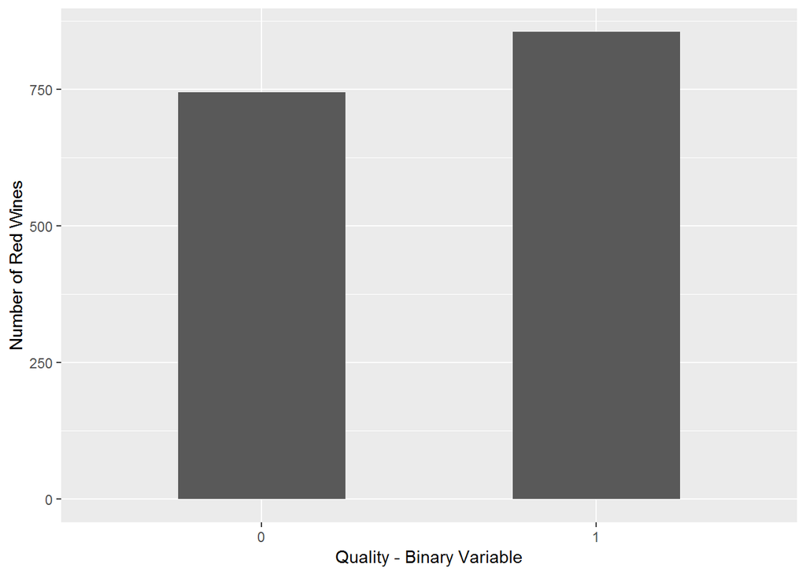

```r
capstone_bar(red, red$binary, "Quality - Binary Variable", "Number of Red Wines")
```

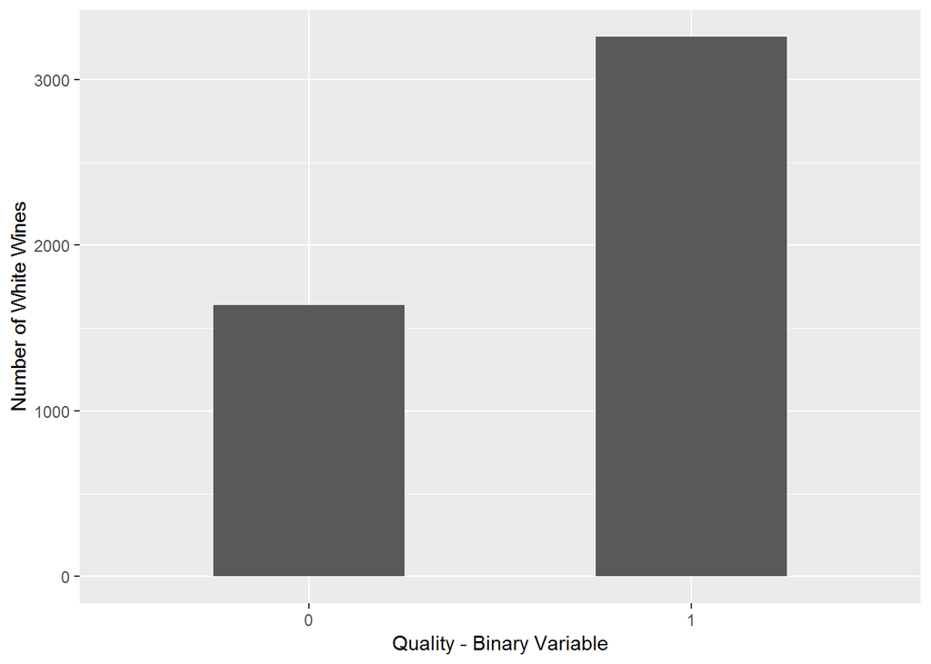

```r
capstone_bar(white, white$binary, "Quality - Binary Variable", "Number of White Wines")
```

The red data set is more balanced than the white data set (e.g. in the red data set 53.4% are good quality, while in the white data set 66.5% are good quality). Handling data imbalance in the predictive model was not attempted in this project because imbalance was not severe. This is a topic that can be explored in future work.

### Box Plots

```r
# Plot ALL boxplots by wine quality rating
capstone_all_boxplots <- function(df) {
  columns <- colnames(df)
  for (i in 1:(length(columns)-1)) {
    print(ggplot(df, aes(x = factor(df$binary), y = df[,i])) +
      geom_boxplot(width = .25) +
      xlab("quality") +
      ylab(columns[i]))
  }
}
```

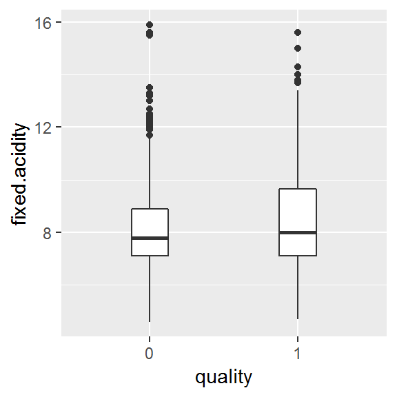

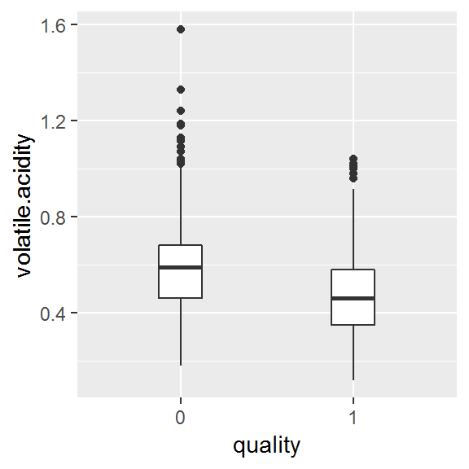

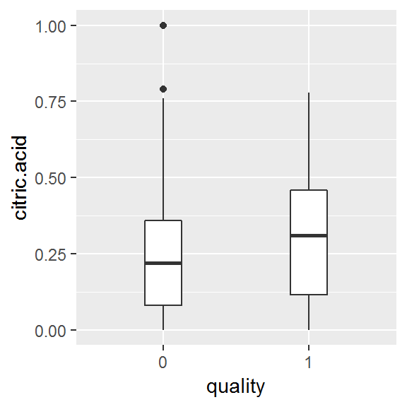

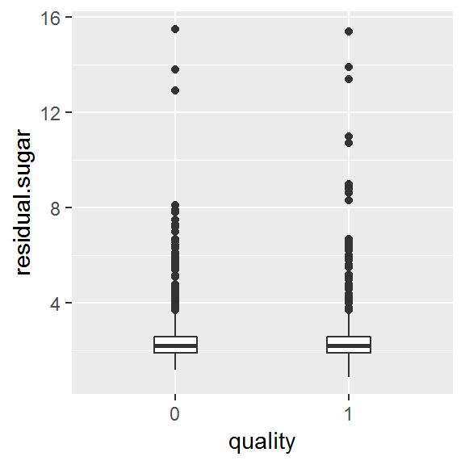

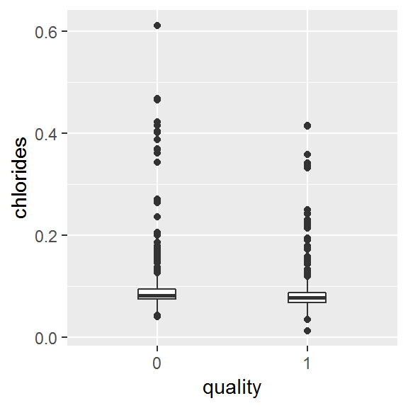

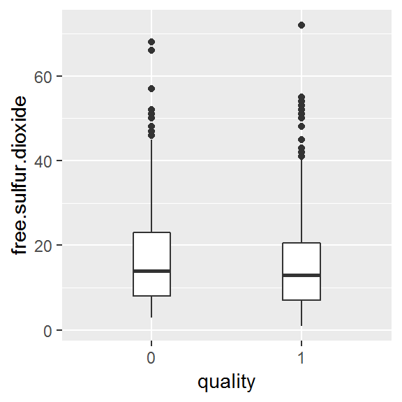

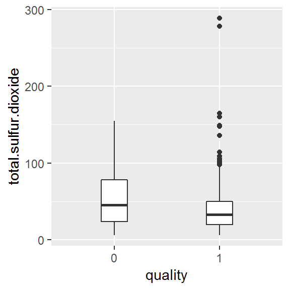

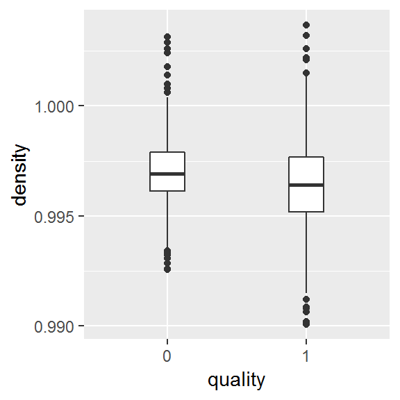

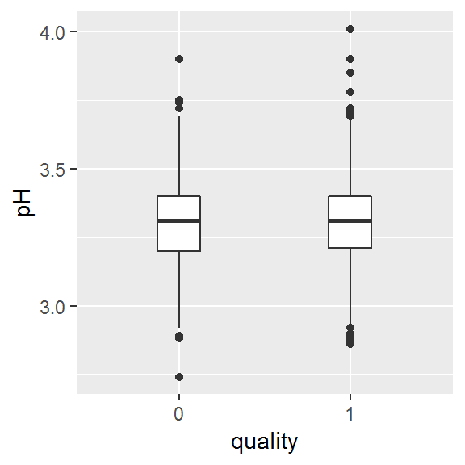

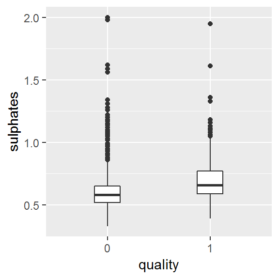

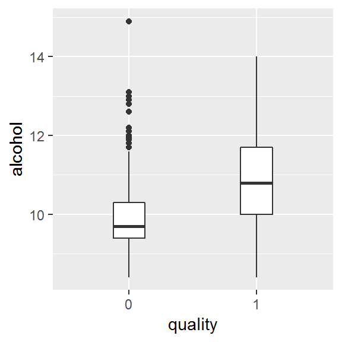

```r
capstone_all_boxplots(red)
```

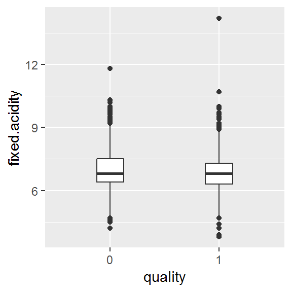

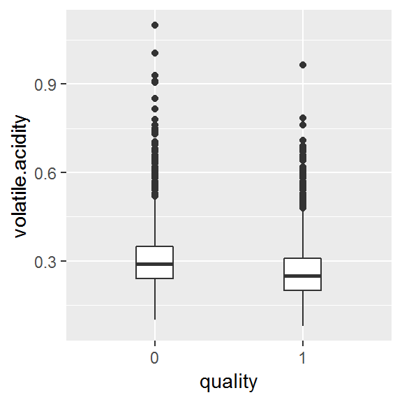

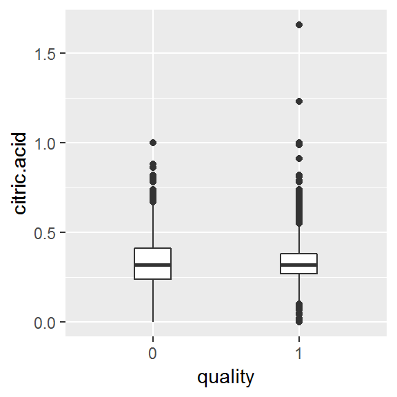

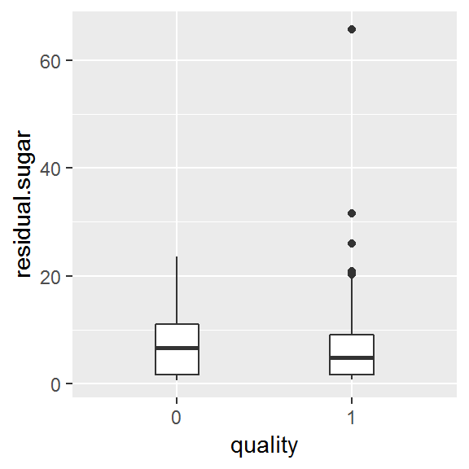

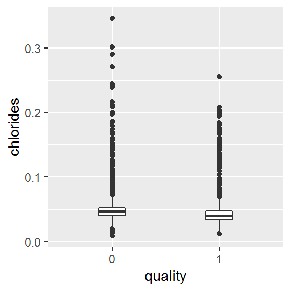

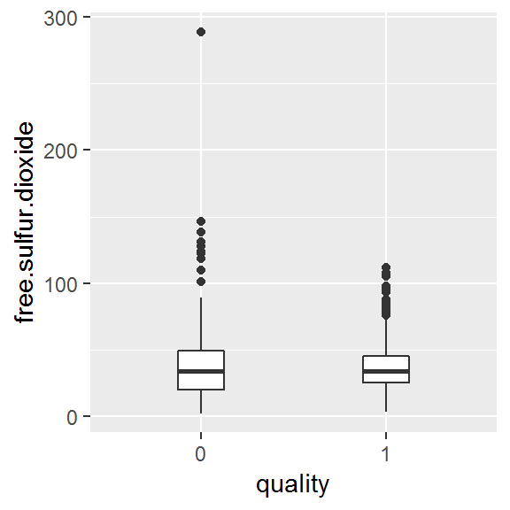

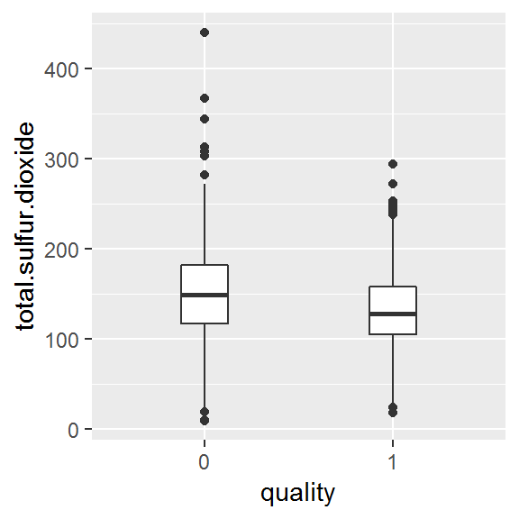

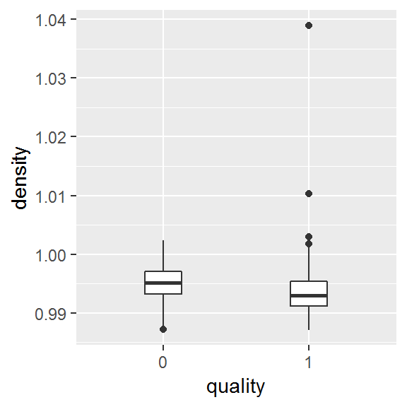

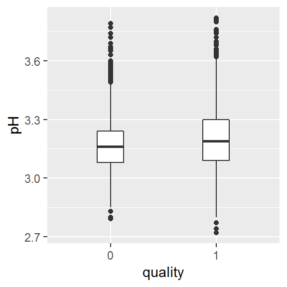

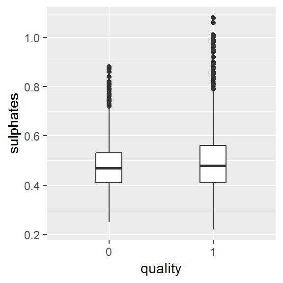

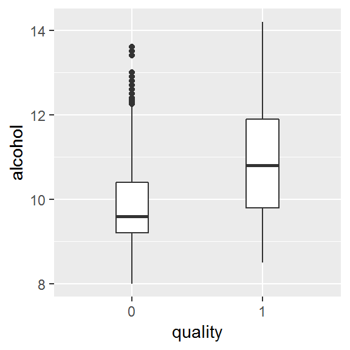

```r
capstone_all_boxplots(white)
```

### Frequency and count charts

```r
# Create frequency table to show how many of each wine quality rating
freq.percent <- function(df, x) {
  qual.freq <- count(df, x) # put actual column name in quotation marks ie. 'column name'
  freq.col <- mutate(qual.freq, "percent" = paste(round((100 * freq/sum(freq)), 0), "%"))
  print(freq.col)
}

# Function to identify number of unique values in each column
unique.all <- function(df) {
  columns <- colnames(df)
  unique.df <- data.frame(matrix(ncol = 2, nrow = 12))
  for (i in 1:12) {
    unique_values <- length(unique(df[,i]))
    unique.df[i, 2] <- unique_values
    unique.df[i, 1] <- columns[i]
  }
  colnames(unique.df) <- c("variable", "unique.values")
  unique.df <- arrange(unique.df, desc(unique.values))
  print(unique.df)
}
```

```r
freq.percent(red, "binary")
```

```
##   binary freq percent
## 1      0  744    47 %
## 2      1  855    53 %
```

```r
freq.percent(white, "binary")
```

```
##   binary freq percent
## 1      0 1640    33 %
## 2      1 3258    67 %
```

```r
unique.all(red)
```

```
##                variable unique.values
## 1               density           436
## 2             chlorides           153
## 3  total.sulfur.dioxide           144
## 4      volatile.acidity           143
## 5         fixed.acidity            96
## 6             sulphates            96
## 7        residual.sugar            91
## 8                    pH            89
## 9           citric.acid            80
## 10              alcohol            65
## 11  free.sulfur.dioxide            60
## 12               binary             2
```

```r
unique.all(white)
```

```
##                variable unique.values
## 1               density           890
## 2        residual.sugar           310
## 3  total.sulfur.dioxide           251
## 4             chlorides           160
## 5   free.sulfur.dioxide           132
## 6      volatile.acidity           125
## 7                    pH           103
## 8               alcohol           103
## 9           citric.acid            87
## 10            sulphates            79
## 11        fixed.acidity            68
## 12               binary             2
```

### Chisquare values

```r
# chi-square test with quality rating
chi.sq <- function(df) {
  columns <- colnames(df)
  pvalue.df <- data.frame(matrix(ncol = 2, nrow = 11))
  for (i in 1:11) {
    test.result <- chisq.test(table(df[,12], df[,i]))
    pvalue.df[i, 2] <- test.result$p.value
    pvalue.df[i, 1] <- columns[i]
  }
  colnames(pvalue.df) <- c("variable", "pvalue")
  pvalue.df <- arrange(pvalue.df, desc(pvalue))
  return(pvalue.df)
}
```

```r
chi.sq(red)
```

```
##                variable       pvalue
## 1   free.sulfur.dioxide 1.586405e-01
## 2                    pH 5.721594e-02
## 3        residual.sugar 2.187560e-03
## 4             chlorides 7.339086e-04
## 5         fixed.acidity 2.907024e-04
## 6               density 2.166644e-05
## 7           citric.acid 5.117090e-08
## 8  total.sulfur.dioxide 2.162763e-10
## 9      volatile.acidity 1.528487e-15
## 10            sulphates 2.737033e-24
## 11              alcohol 1.099768e-50
```

```r
chi.sq(white)
```

```
##                variable        pvalue
## 1             sulphates  6.417315e-05
## 2                    pH  7.565130e-08
## 3         fixed.acidity  7.224627e-12
## 4        residual.sugar  1.212742e-25
## 5   free.sulfur.dioxide  3.319982e-32
## 6      volatile.acidity  1.183272e-32
## 7  total.sulfur.dioxide  5.152837e-37
## 8             chlorides  4.519228e-41
## 9               density  4.989933e-42
## 10          citric.acid  5.972261e-50
## 11              alcohol 2.658931e-121
```

### Correlation tables

```r
# Calculate correlation coefficient table for all values

kable(cor(red), digits = 2)
```

|  | fixed.acidity | volatile.acidity | citric.acid | residual.sugar | chlorides | free.sulfur.dioxide | total.sulfur.dioxide | density | pH | sulphates | alcohol | binary |
| --- | --- | --- | --- | --- | --- | --- | --- | --- | --- | --- | --- | --- |
| fixed.acidity | 1.00 | -0.26 | 0.67 | 0.11 | 0.09 | -0.15 | -0.11 | 0.67 | -0.68 | 0.18 | -0.06 | 0.10 |
| volatile.acidity | -0.26 | 1.00 | -0.55 | 0.00 | 0.06 | -0.01 | 0.08 | 0.02 | 0.23 | -0.26 | -0.20 | -0.32 |
| citric.acid | 0.67 | -0.55 | 1.00 | 0.14 | 0.20 | -0.06 | 0.04 | 0.36 | -0.54 | 0.31 | 0.11 | 0.16 |
| residual.sugar | 0.11 | 0.00 | 0.14 | 1.00 | 0.06 | 0.19 | 0.20 | 0.36 | -0.09 | 0.01 | 0.04 | 0.00 |
| chlorides | 0.09 | 0.06 | 0.20 | 0.06 | 1.00 | 0.01 | 0.05 | 0.20 | -0.27 | 0.37 | -0.22 | -0.11 |
| free.sulfur.dioxide | -0.15 | -0.01 | -0.06 | 0.19 | 0.01 | 1.00 | 0.67 | -0.02 | 0.07 | 0.05 | -0.07 | -0.06 |
| total.sulfur.dioxide | -0.11 | 0.08 | 0.04 | 0.20 | 0.05 | 0.67 | 1.00 | 0.07 | -0.07 | 0.04 | -0.21 | -0.23 |
| density | 0.67 | 0.02 | 0.36 | 0.36 | 0.20 | -0.02 | 0.07 | 1.00 | -0.34 | 0.15 | -0.50 | -0.16 |
| pH | -0.68 | 0.23 | -0.54 | -0.09 | -0.27 | 0.07 | -0.07 | -0.34 | 1.00 | -0.20 | 0.21 | 0.00 |
| sulphates | 0.18 | -0.26 | 0.31 | 0.01 | 0.37 | 0.05 | 0.04 | 0.15 | -0.20 | 1.00 | 0.09 | 0.22 |
| alcohol | -0.06 | -0.20 | 0.11 | 0.04 | -0.22 | -0.07 | -0.21 | -0.50 | 0.21 | 0.09 | 1.00 | 0.43 |
| binary | 0.10 | -0.32 | 0.16 | 0.00 | -0.11 | -0.06 | -0.23 | -0.16 | 0.00 | 0.22 | 0.43 | 1.00 |

```r
kable(cor(white), digits = 2)
```

|  | fixed.acidity | volatile.acidity | citric.acid | residual.sugar | chlorides | free.sulfur.dioxide | total.sulfur.dioxide | density | pH | sulphates | alcohol | binary |
| --- | --- | --- | --- | --- | --- | --- | --- | --- | --- | --- | --- | --- |
| fixed.acidity | 1.00 | -0.02 | 0.29 | 0.09 | 0.02 | -0.05 | 0.09 | 0.27 | -0.43 | -0.02 | -0.12 | -0.09 |
| volatile.acidity | -0.02 | 1.00 | -0.15 | 0.06 | 0.07 | -0.10 | 0.09 | 0.03 | -0.03 | -0.04 | 0.07 | -0.23 |
| citric.acid | 0.29 | -0.15 | 1.00 | 0.09 | 0.11 | 0.09 | 0.12 | 0.15 | -0.16 | 0.06 | -0.08 | 0.00 |
| residual.sugar | 0.09 | 0.06 | 0.09 | 1.00 | 0.09 | 0.30 | 0.40 | 0.84 | -0.19 | -0.03 | -0.45 | -0.09 |
| chlorides | 0.02 | 0.07 | 0.11 | 0.09 | 1.00 | 0.10 | 0.20 | 0.26 | -0.09 | 0.02 | -0.36 | -0.18 |
| free.sulfur.dioxide | -0.05 | -0.10 | 0.09 | 0.30 | 0.10 | 1.00 | 0.62 | 0.29 | 0.00 | 0.06 | -0.25 | 0.00 |
| total.sulfur.dioxide | 0.09 | 0.09 | 0.12 | 0.40 | 0.20 | 0.62 | 1.00 | 0.53 | 0.00 | 0.13 | -0.45 | -0.17 |
| density | 0.27 | 0.03 | 0.15 | 0.84 | 0.26 | 0.29 | 0.53 | 1.00 | -0.09 | 0.07 | -0.78 | -0.27 |
| pH | -0.43 | -0.03 | -0.16 | -0.19 | -0.09 | 0.00 | 0.00 | -0.09 | 1.00 | 0.16 | 0.12 | 0.08 |
| sulphates | -0.02 | -0.04 | 0.06 | -0.03 | 0.02 | 0.06 | 0.13 | 0.07 | 0.16 | 1.00 | -0.02 | 0.05 |
| alcohol | -0.12 | 0.07 | -0.08 | -0.45 | -0.36 | -0.25 | -0.45 | -0.78 | 0.12 | -0.02 | 1.00 | 0.38 |
| binary | -0.09 | -0.23 | 0.00 | -0.09 | -0.18 | 0.00 | -0.17 | -0.27 | 0.08 | 0.05 | 0.38 | 1.00 |

There is strong correlation between some of the physiochemical properties collected in the data.

From these correlation estimates, lower volatile acidity and higher alcohol content leans toward a quality red wine.

Higher alcohol content leans toward a quality white wine. A couple other variables to take notice are volatile acidity and density that are almost moderately correlated.

### Quantiles

```r
# Identify 1%, 5%, 10%, 90%, 99%, and 100% range
quantile.all <- function(df) {
  columns <- colnames(df)
  quant.df <- data.frame(matrix(ncol = 6, nrow = 12))
  probability <- c(.01, .05, .1, .90, .99, 1)
  for (i in 1:length(columns)) {
    quantile.variable <- quantile(df[,i], probs = probability)
    quant.df[i, ] <- quantile.variable
  }
  quant.df <- cbind(columns, quant.df)
  names(quant.df) <- c("variable", ".01", ".05", ".1", ".90", ".99", "1")
  print(quant.df)
}
```

```r
quantile.all(red)
```

```
##                variable     .01       .05        .1      .90        .99
## 1         fixed.acidity 5.20000  6.100000  6.500000 10.70000  13.300000
## 2      volatile.acidity 0.19000  0.270000  0.310000  0.74500   1.020000
## 3           citric.acid 0.00000  0.000000  0.010000  0.52200   0.700200
## 4        residual.sugar 1.40000  1.590000  1.700000  3.60000   8.306000
## 5             chlorides 0.04298  0.054000  0.060000  0.10900   0.360160
## 6   free.sulfur.dioxide 3.00000  4.000000  5.000000 31.00000  50.020000
## 7  total.sulfur.dioxide 8.00000 11.000000 14.000000 93.20000 145.000000
## 8               density 0.99182  0.993598  0.994556  0.99914   1.001506
## 9                    pH 2.93000  3.060000  3.120000  3.51000   3.700200
## 10            sulphates 0.42000  0.470000  0.500000  0.85000   1.260400
## 11              alcohol 9.00000  9.200000  9.300000 12.00000  13.400000
## 12               binary 0.00000  0.000000  0.000000  1.00000   1.000000
##            1
## 1   15.90000
## 2    1.58000
## 3    1.00000
## 4   15.50000
## 5    0.61100
## 6   72.00000
## 7  289.00000
## 8    1.00369
## 9    4.01000
## 10   2.00000
## 11  14.90000
## 12   1.00000
```

```r
quantile.all(white)
```

```
##                variable        .01        .05        .1       .90
## 1         fixed.acidity  5.0000000  5.6000000  5.900000   7.90000
## 2      volatile.acidity  0.1200000  0.1500000  0.170000   0.40000
## 3           citric.acid  0.0500000  0.1700000  0.220000   0.49000
## 4        residual.sugar  0.9000000  1.1000000  1.200000  14.00000
## 5             chlorides  0.0200000  0.0270000  0.030000   0.05800
## 6   free.sulfur.dioxide  6.0000000 11.0000000 15.000000  57.00000
## 7  total.sulfur.dioxide 50.9700000 75.0000000 87.000000 195.00000
## 8               density  0.9887794  0.9896385  0.990327   0.99815
## 9                    pH  2.8800000  2.9600000  3.000000   3.38000
## 10            sulphates  0.2900000  0.3400000  0.360000   0.64000
## 11              alcohol  8.7000000  8.9000000  9.000000  12.40000
## 12               binary  0.0000000  0.0000000  0.000000   1.00000
##           .99         1
## 1    9.200000  14.20000
## 2    0.630000   1.10000
## 3    0.740000   1.66000
## 4   18.800000  65.80000
## 5    0.160000   0.34600
## 6   81.000000 289.00000
## 7  241.030000 440.00000
## 8    1.000302   1.03898
## 9    3.600000   3.82000
## 10   0.830000   1.08000
## 11  13.400000  14.20000
## 12   1.000000   1.00000
```

## Analysis Approach: Training and Testing Sets

Each data set (red and white wine) was separated into a training and testing set. We can use the training set and then our testing set to assess the performance of the model. This is a standard method to evaluate the model and check whether it overfits the training data. Our goal is to find a model that performs similarly in both training and testing set.

The caTools package was used to split the data into training (67%) and testing (33%) sets.

```r
# Split data using sample.split function

capstone_training <- function(dfcol, dataframe) {
  set.seed(123456)
  split <- sample.split(dfcol, SplitRatio = .67)
  training.set <- subset(dataframe, split == TRUE)
  return(training.set)
}

capstone_testing <- function(dfcol, dataframe) {
  set.seed(123456)
  split <- sample.split(dfcol, SplitRatio = .67)
  testing.set <- subset(dataframe, split == FALSE)
  return(testing.set)
}

# Create training and testing sets
redTrain <- capstone_training(red$binary, red)
redTest <- capstone_testing(red$binary, red)

whiteTrain <- capstone_training(white$binary, white)
whiteTest <- capstone_testing(white$binary, white)
```

## Create GLM and Prediction Models

Once the data was split, a GLM (generalized linear model) was created to identify which variables were significant to the quality of wine.

Two methods were used to idenify the significan variables.

1. Use all variables in glm model

```r
# glm with all variables
redTrain.glm.all <- glm(binary ~ . , data = redTrain, family = binomial)
summary(redTrain.glm.all)
```

```
##
## Call:
## glm(formula = binary ~ ., family = binomial, data = redTrain)
##
## Deviance Residuals:
##     Min       1Q   Median       3Q      Max
## -3.4731  -0.8624   0.3159   0.8308   2.1643
##
## Coefficients:
##                        Estimate Std. Error z value Pr(>|z|)
## (Intercept)           1.292e+02  9.562e+01   1.351  0.17680
## fixed.acidity         2.040e-01  1.206e-01   1.691  0.09085 .
## volatile.acidity     -2.459e+00  5.580e-01  -4.407 1.05e-05 ***
## citric.acid          -6.188e-01  6.609e-01  -0.936  0.34909
## residual.sugar        7.364e-02  6.727e-02   1.095  0.27360
## chlorides            -3.535e+00  1.913e+00  -1.847  0.06468 .
## free.sulfur.dioxide   1.306e-02  9.932e-03   1.315  0.18846
## total.sulfur.dioxide -1.205e-02  3.350e-03  -3.599  0.00032 ***
## density              -1.401e+02  9.764e+01  -1.435  0.15136
## pH                    2.075e-01  8.700e-01   0.239  0.81148
## sulphates             2.760e+00  5.519e-01   5.001 5.71e-07 ***
## alcohol               8.114e-01  1.247e-01   6.508 7.64e-11 ***
## ---
## Signif. codes:  0 '***' 0.001 '**' 0.01 '*' 0.05 '.' 0.1 ' ' 1
##
## (Dispersion parameter for binomial family taken to be 1)
##
##     Null deviance: 1479.5  on 1070  degrees of freedom
## Residual deviance: 1127.7  on 1059  degrees of freedom
## AIC: 1151.7
##
## Number of Fisher Scoring iterations: 4
```

```r
# glm with all variables
whiteTrain.glm.all <- glm(binary ~ . , data = whiteTrain, family = binomial)
summary(whiteTrain.glm.all)
```

```
##
## Call:
## glm(formula = binary ~ ., family = binomial, data = whiteTrain)
##
## Deviance Residuals:
##     Min       1Q   Median       3Q      Max
## -2.6902  -0.8957   0.4440   0.7977   2.5535
##
## Coefficients:
##                        Estimate Std. Error z value Pr(>|z|)
## (Intercept)           3.905e+02  9.081e+01   4.300 1.71e-05 ***
## fixed.acidity         7.799e-02  8.887e-02   0.878  0.38017
## volatile.acidity     -6.385e+00  5.133e-01 -12.439  < 2e-16 ***
## citric.acid           3.770e-01  3.646e-01   1.034  0.30103
## residual.sugar        2.059e-01  3.412e-02   6.036 1.58e-09 ***
## chlorides             9.267e-01  2.056e+00   0.451  0.65213
## free.sulfur.dioxide   8.969e-03  3.428e-03   2.616  0.00889 **
## total.sulfur.dioxide -1.331e-03  1.483e-03  -0.897  0.36970
## density              -4.035e+02  9.201e+01  -4.385 1.16e-05 ***
## pH                    1.341e+00  4.482e-01   2.993  0.00277 **
## sulphates             2.322e+00  4.471e-01   5.192 2.08e-07 ***
## alcohol               5.428e-01  1.180e-01   4.598 4.26e-06 ***
## ---
## Signif. codes:  0 '***' 0.001 '**' 0.01 '*' 0.05 '.' 0.1 ' ' 1
##
## (Dispersion parameter for binomial family taken to be 1)
##
##     Null deviance: 4185.0  on 3281  degrees of freedom
## Residual deviance: 3309.2  on 3270  degrees of freedom
## AIC: 3333.2
##
## Number of Fisher Scoring iterations: 5
```

2. Use stepwise method to select a subset of variables

```r
# glm with stepAIC function from MASS package. Slight variation in model.

# stepAIC model selection by AIC
redTrain.glm.sw <- stepAIC(redTrain.glm.all, trace = FALSE)
summary(redTrain.glm.sw)
```

```
##
## Call:
## glm(formula = binary ~ fixed.acidity + volatile.acidity + chlorides +
##     free.sulfur.dioxide + total.sulfur.dioxide + sulphates +
##     alcohol, family = binomial, data = redTrain)
##
## Deviance Residuals:
##     Min       1Q   Median       3Q      Max
## -3.2958  -0.8542   0.3242   0.8383   2.2209
##
## Coefficients:
##                       Estimate Std. Error z value Pr(>|z|)
## (Intercept)          -9.608401   1.098417  -8.747  < 2e-16 ***
## fixed.acidity         0.063392   0.044532   1.424    0.155
## volatile.acidity     -2.330716   0.453931  -5.135 2.83e-07 ***
## chlorides            -3.925939   1.726870  -2.273    0.023 *
## free.sulfur.dioxide   0.014464   0.009622   1.503    0.133
## total.sulfur.dioxide -0.012346   0.003021  -4.086 4.39e-05 ***
## sulphates             2.536938   0.526708   4.817 1.46e-06 ***
## alcohol               0.917475   0.085443  10.738  < 2e-16 ***
## ---
## Signif. codes:  0 '***' 0.001 '**' 0.01 '*' 0.05 '.' 0.1 ' ' 1
##
## (Dispersion parameter for binomial family taken to be 1)
##
##     Null deviance: 1479.5  on 1070  degrees of freedom
## Residual deviance: 1131.1  on 1063  degrees of freedom
## AIC: 1147.1
##
## Number of Fisher Scoring iterations: 4
```

```r
whiteTrain.glm.sw <- stepAIC(whiteTrain.glm.all, trace = FALSE)
summary(whiteTrain.glm.sw)
```

```
##
## Call:
## glm(formula = binary ~ volatile.acidity + residual.sugar + free.sulfur.dioxide +
##     density + pH + sulphates + alcohol, family = binomial, data = whiteTrain)
##
## Deviance Residuals:
##     Min       1Q   Median       3Q      Max
## -2.6893  -0.9029   0.4432   0.8029   2.5434
##
## Coefficients:
##                       Estimate Std. Error z value Pr(>|z|)
## (Intercept)          3.285e+02  5.594e+01   5.873 4.28e-09 ***
## volatile.acidity    -6.595e+00  4.945e-01 -13.337  < 2e-16 ***
## residual.sugar       1.815e-01  2.236e-02   8.117 4.78e-16 ***
## free.sulfur.dioxide  7.350e-03  2.744e-03   2.679  0.00739 **
## density             -3.399e+02  5.603e+01  -6.067 1.30e-09 ***
## pH                   9.669e-01  3.126e-01   3.093  0.00198 **
## sulphates            2.201e+00  4.338e-01   5.074 3.90e-07 ***
## alcohol              6.245e-01  8.225e-02   7.593 3.13e-14 ***
## ---
## Signif. codes:  0 '***' 0.001 '**' 0.01 '*' 0.05 '.' 0.1 ' ' 1
##
## (Dispersion parameter for binomial family taken to be 1)
##
##     Null deviance: 4185.0  on 3281  degrees of freedom
## Residual deviance: 3312.4  on 3274  degrees of freedom
## AIC: 3328.4
##
## Number of Fisher Scoring iterations: 5
```

After looking at the summary of the models, the models that used the stepwise method provided a lower AIC. Since lower AIC between models using the same data set is ideal, these models were carried forward in the analysis.

By looking at the p-values, we can find which attributes are more significantly associated with wine quality. For example, for the white wine all p-values are smaller than .05. Further, by looking at the parameter estimates we can derive whether high or low values of the attribute are better for good quality wine. For example the sign of volatile.acidity is negative, thus the lower the value of this variable the higher the probability of good quality wine.

## Model Evaluation and Metrics

### Prediction Models

Running the predict function on the models provided probabilities for the binary variables.

```r
# Use glm model with specific significant variables to run predictions
predict.redTrain <- predict(redTrain.glm.sw, type = "response")
summary(predict.redTrain)
```

```
##    Min. 1st Qu.  Median    Mean 3rd Qu.    Max.
## 0.02852 0.29656 0.51166 0.53501 0.79278 0.99562
```

```r
# Identify average probablity of binary variable on training set. 0 = 37.8%; 1 = 67.1%
tapply(predict.redTrain, redTrain$binary, mean)
```

```
##        0        1
## 0.378402 0.671127
```

```r
# Use glm model with specific significant variables to run predictions
predict.whiteTrain <- predict(whiteTrain.glm.sw, type = "response")
summary(predict.whiteTrain)
```

```
##     Min.  1st Qu.   Median     Mean  3rd Qu.     Max.
## 0.002416 0.502754 0.705134 0.665143 0.868710 0.992237
```

```r
# Identify average probablity of binary variable on training set. 0 = 50%; 1 = 74.7%
tapply(predict.whiteTrain, whiteTrain$binary, mean)
```

```
##         0         1
## 0.5011334 0.7477116
```

### Confusion Matrix

By setting the threshold rate to greater than 50%, a confusion matrix was created to identify the sensitivity, specificity and accuracy rate.

```r
# Set threshold value to 50%; no preference on either rate at this point. Check confusion matrix; accuracy = 75%
table(redTrain$binary, predict.redTrain > 0.50)
```

```
##
##     FALSE TRUE
##   0   377  121
##   1   150  423
```

```r
# Set threshold value to 50%; no preference on either rate at this point. Check confusion matrix; accuracy = 75%
table(whiteTrain$binary, predict.whiteTrain > 0.50)
```

```
##
##     FALSE TRUE
##   0   543  556
##   1   267 1916
```

### ROC Curve and AUC

The ROC curve was plotted showing the false positive rate against the true positive rate. The AUC was calculated at 81.4% for red and 80% for white.

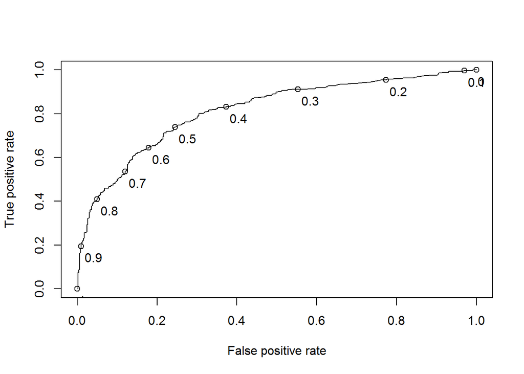

```r
# To plot an ROC, create a prediction model to standardize format
ROCRpred.redTrain <- prediction(predict.redTrain, redTrain$binary)
ROCRperf.redTrain <- performance(ROCRpred.redTrain, "tpr", "fpr")
# Plot ROCR
plot(ROCRperf.redTrain, colorsize = TRUE, print.cutoffs.at=seq(0,1,0.1), text.adj = c(-.2,1.7))
```

```r
# Identify AUC = 81%
as.numeric(performance(ROCRpred.redTrain, "auc")@y.values)
```

```
## [1] 0.8140766
```

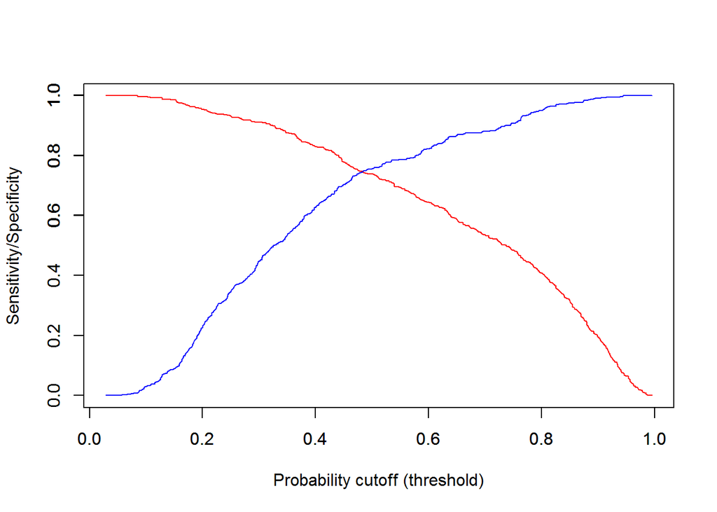

```r
#ROCR performance of sensitivity and specificity
Sens.ROCRpred.redTrain <- performance(ROCRpred.redTrain,  measure="sens", x.measure="cutoff")
Spec.ROCRpred.redTrain <- performance(ROCRpred.redTrain,  measure="spec", x.measure="cutoff")

# Plot sensitivity and specificity rates to find where they intersect as best tradeoff between rates
plot(Sens.ROCRpred.redTrain, type="l", col="red",xlab="",ylab="")
par(new=TRUE)
plot(Spec.ROCRpred.redTrain, type="l", col="blue", xlab="Probability cutoff (threshold)",ylab="Sensitivity/Specificity")
```

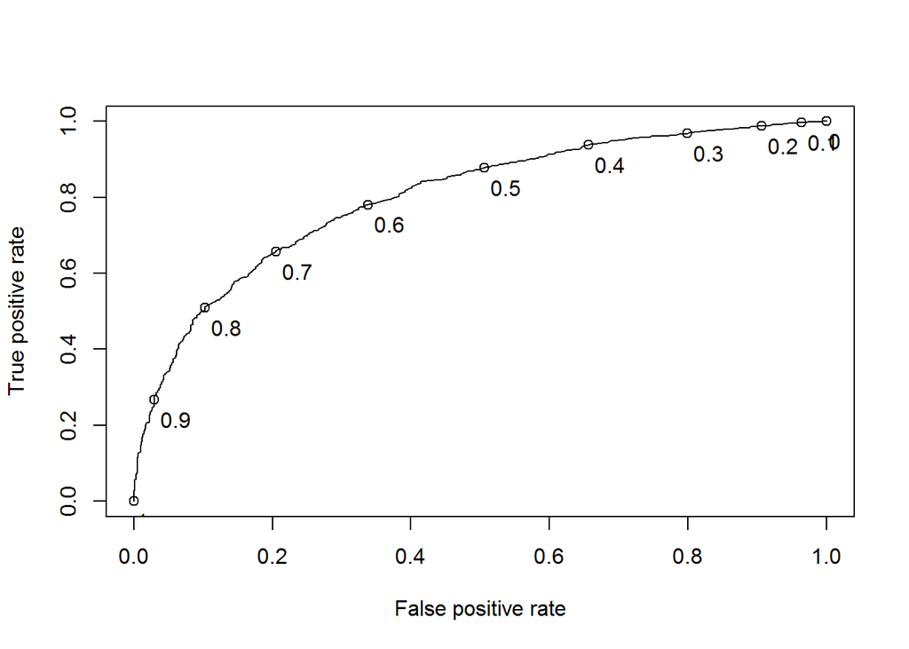

```r
# To plot an ROC, create a prediction model to standardize format
ROCRpred.whiteTrain <- prediction(predict.whiteTrain, whiteTrain$binary)
ROCRperf.whiteTrain <- performance(ROCRpred.whiteTrain, "tpr", "fpr")
# Plot ROCR
plot(ROCRperf.whiteTrain, colorsize = TRUE, print.cutoffs.at=seq(0,1,0.1), text.adj = c(-.2,1.7))
```

```r
# Identify AUC = 80%
as.numeric(performance(ROCRpred.whiteTrain, "auc")@y.values)
```

```
## [1] 0.8004562
```

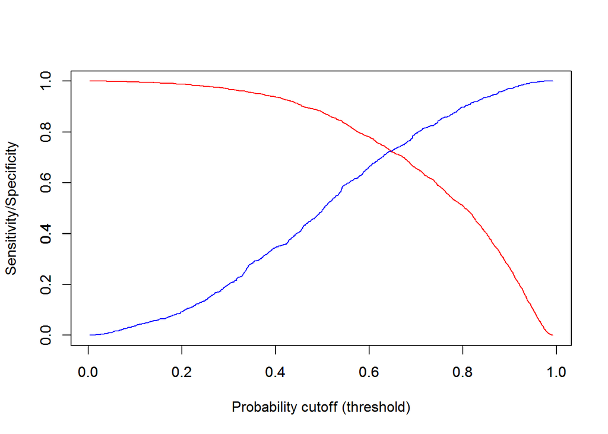

```r
#ROCR performance of sensitivity and specificity
Sens.ROCRpred.whiteTrain <- performance(ROCRpred.whiteTrain,  measure="sens", x.measure="cutoff")
Spec.ROCRpred.whiteTrain <- performance(ROCRpred.whiteTrain,  measure="spec", x.measure="cutoff")

# Plot sensitivity and specificity rates to find where they intersect as best tradeoff between rates
plot(Sens.ROCRpred.whiteTrain, type="l", col="red",xlab="",ylab="")
par(new=TRUE)
plot(Spec.ROCRpred.whiteTrain, type="l", col="blue", xlab="Probability cutoff (threshold)",ylab="Sensitivity/Specificity")
```

## Apply Testing Sets to Prediction Models

The testing data was incorporated into the prediction model created with the training set. The same steps were performed on the data. The results showed similar results withe sensitivity, specificity, and accuracy rate. The ROC curve and AUC only varied slightly proving that our model has consistently performed on new data.

```r
#-----Apply testing set to model-----

# Testing data set already created in earlier steps
# Use glm model from training set to apply to testing set
predict.redTest <- predict(redTrain.glm.sw, type = "response", newdata = redTest)
summary(predict.redTest)
```

```
##    Min. 1st Qu.  Median    Mean 3rd Qu.    Max.
## 0.02688 0.28701 0.51637 0.52566 0.77709 0.98596
```

```r
# Identify average probablity of binary variable on training set. 0 = 36.5%; 1 = 66.5%
tapply(predict.redTest, redTest$binary, mean)
```

```
##         0         1
## 0.3650934 0.6657357
```

```r
#-----Plot ROCR and identify AUC-----

# Set threshold value to 50% as was done with train set; accuracy = 74%
table(redTest$binary, predict.redTest > 0.5)
```

```
##
##     FALSE TRUE
##   0   181   65
##   1    75  207
```

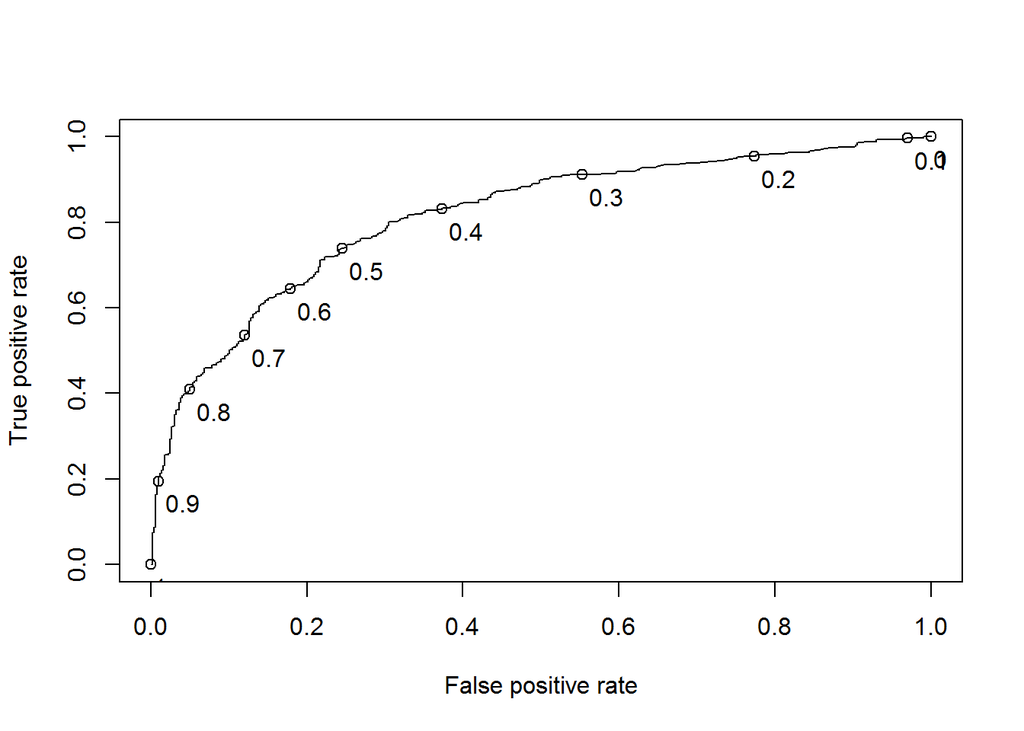

```r
# To plot an ROC, create a prediction model to standardize format
ROCRpred.redTest <- prediction(predict.redTest, redTest$binary)
ROCRperf.redTest <- performance(ROCRpred.redTest, "tpr", "fpr")
# Plot ROCR
plot(ROCRperf.redTrain, colorsize = TRUE, print.cutoffs.at=seq(0,1,0.1), text.adj = c(-.2,1.7))
```

```r
ROCRpred.redTest <- prediction(predict.redTest, redTest$binary)
# Identify AUC = 82%
as.numeric(performance(ROCRpred.redTest, "auc")@y.values)
```

```
## [1] 0.827625
```

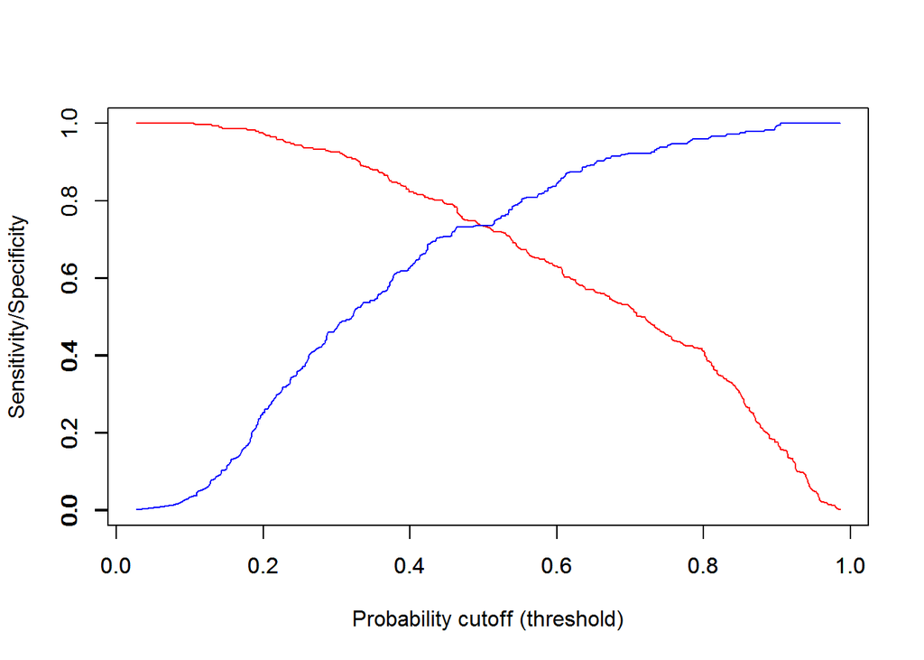

```r
#ROCR performance of sensitivity and specificity
Sens.ROCRpred.redTest <- performance(ROCRpred.redTest,  measure="sens", x.measure="cutoff")
Spec.ROCRpred.redTest <- performance(ROCRpred.redTest,  measure="spec", x.measure="cutoff")

# Plot sensitivity and specificity rates to find where they intersect as best tradeoff between rates
plot(Sens.ROCRpred.redTest, type="l", col="red",xlab="",ylab="")
par(new=TRUE)
plot(Spec.ROCRpred.redTest, type="l", col="blue", xlab="Probability cutoff (threshold)",ylab="Sensitivity/Specificity")
```

```r
#-----Apply testing set to model-----

# Testing data set already created in earlier steps
# Use glm model from training set to apply to testing set
predict.whiteTest <- predict(whiteTrain.glm.sw, type = "response", newdata = whiteTest)
summary(predict.whiteTest)
```

```
##      Min.   1st Qu.    Median      Mean   3rd Qu.      Max.
## 0.0009725 0.5063071 0.7117600 0.6657905 0.8660665 0.9926941
```